# kuo_timothy_finaltermprojectoption1

## CS 634 - Data Mining Final Project

Name: Timothy Kuo

UCID: tk345

Preferred email address: timykuo@gmail.com

Project option: Option 1 (Classification)

Note: It may be easier to view it as a HTML instead of a pdf since this was created in jupyter notebook. You can view the HTML version here: http://www.timkuo.com/pages/datamining_proj

### Algorithms

1. Category 3 (Decision Trees) - J48 (C4.5)
2. Category 5 (Naive Bayes) - NaiveBayes

#### Decision Tree

Decision tree includes implementation for nominal and continuous attributes, and uses both information gain and gain ratio as the split criterion (depending on a provided option below). Also implements stratified cross validation as described below. The code takes four options:

1. Option 1 is the path to the data. If this is “/a/b/someproblem” then it loads “/a/b/someproblem.names” and “/a/b/someproblem.data”.
2. Option 2 is to use cross validation or the full sample. If 0, use 10-fold cross validation. If 1, use the full sample.
3. Option 3 is a nonnegative integer that sets the maximum depth of the tree (the number of tests on any path from root to leaf). If this value is zero, it grows the full tree. If this value is positive, it grows the tree to the given value. Note that if this value is too large, it will have the same effect as when the option is zero.
4. Option 4 is a 0/1 option. If 0, it uses information gain as the split criterion. If 1, it uses gain ratio.

#### Naïve Bayes

Implementation of the naïve Bayes algorithm discretizes continuous values by partitioning the range of the feature into k bins (value set through an option). Then, it replaces the feature with a discrete feature that takes value x if the original feature’s value was in bin x. Uses m-estimates to smooth probability estimates. Uses logs whenever possible to avoid multiplying too many probabilities together. The main file is called nbayes. The code takes four options:

1. Option 1 will be the path to the data (see Decision Tree Learner).
2. Option 2 is to use cross validation or the full sample. If 0, use 10-fold cross validation. If 1, use the full sample.
3. Option 3 (at least 2) is the number of bins for any continuous feature.
4. Option 4 is the value of m for the m-estimate. If this value is negative, uses Laplace smoothing.

Note that m=0 is maximum likelihood estimation. The value of p in the m-estimate should be fixed to 1/v for a variable with v values.

#### Output

For this project, I've split up what would be in the main method of the user interactive file (classifier.py) in the section below to explain how it works. The main method should first construct 10 folds using stratified cross validation if this option is provided. To ensure repeatability, it sets the random seed for the PRNG to 12345. Then it produces decision trees/naive bayes models on each fold (or the sample according to the option) and produces output in the following format:

Accuracy: 0.xyz 0.abc  
Precision: 0.xyz 0.abc  
Recall: 0.xyz 0.abc

where "0.xyz" is the average accuracy among all the folds and "0.abc" is the standard deviation among all the folds.

### Code Breakdown

All code described below is attached. In addition, explanation on commands to obtain the outputs that I have are described in each individual section. This section is for breaking down the organization of the source code and how they are connected.

##### Classifiers

Since the two algorithms that I chose are relatively simple, I decided to implement them on my own in two files, "dtree.py" and "nbayes.py". "dtree.py" also has an attached file called "tree_struct.py" that holds the implementation for the nodes of the decision tree. Finally, a main file called "classifier.py" holds both of these classifiers as classes that the user can interact with. Thus, the options described above are input requirements when creating the classifier. Each classifier has a classify function that takes in an example as input and outputs the resulting class. In addition, a file called "percentage_split.py" imports the classifier.py file to complete percentage tests instead of cross validation.

##### Utility

I have a file called "util.py" that contains code necessary for both algorithms. In addition, I have two other files, "csv_to_c45.py" that parses the csv file into a seperate "< dataset_name >.names" and "< dataset_name >.data" files to make it easier to use for my classification algorithms. "parser.py" then parses these files to classify each column as either the index, an attribute (continuous, nominal, binary, class) and each row as an example.

##### Output

"statistics.py" is the main file for "classifier.py" and "percentage_split.py" to pass in the results of the classifcation model so that a contingency table/confusion matrix can be created. From the tables/matrixes, we can calculate accuracy, precision, and recall and also the standard deviation of the folds as described in the section above.

### Dataset

For the dataset, I chose the "Bank Marketing" dataset from http://archive.ics.uci.edu/ml/datasets/Bank+Marketing. In the folder "bank", bank.info contains the description of the different attributes as well as the type of value (continuous/categorical/binary) as well as background information from the data provider, bank.data is the actual data, and bank.names is the name and values of the attributes. In the source code, there are 2 files used to parse and organize the data: csv_to_c45.py parses the raw data and organizes it so that parser.py can assign classes to the data points and their features for the classification algorithms.

### Setup/Main Method of classifier.py

**Note**: I am describing the main method of classifier.py in the following section, you can also easily run the code by itself through "python3 classifier.py < algo_name > < algo_options >" where algo_name is either dtree or nbayes, and the algo_options are described above.

The first step to begin is to first import all the necessary classes. Since our code is implemented through a main class, "classifier", we will import that as well as some useful python data visualization libraries to evaluate the algorithms.

```python
import matplotlib.pyplot as plt
from matplotlib import pyplot
%matplotlib inline
import numpy as np
from pylab import *
import pandas as pd
import seaborn as sns
import sys
from IPython.display import HTML, display
import tabulate
from statistics import Statistics
from classifier import DTree, NBayes
from util import get_examples, nfold, split_folds
```

Next, there are some global variables to create since we would like to ensure repeatability by other users, as well as some other variables we will be using to run the algorithms. In particular, NUM_FOLDS is for determing how many folds to use in n-fold cross validation. Since we are going to be using 10-fold cross validation, we will set it as 10 in our case. Next, the SEED is to ensure repeatability by other users. During 10-fold cross validation, we randomly select some examples using python's random library. Setting the seed allows for repeating the same random experiment. Finally, USE_ALL_TABLES is used as an option for the statistics library. Since we want to view the data across all tables, we use -1 instead of a specific number that would specify which fold to output the accuracy/precision/recall.

```python
NUM_FOLDS = 10
SEED = 12345
USE_ALL_TABLES = -1
```

From here, we can create a new classifier and test it on our dataset. Each classifier has an input for the path to the example (in our case, the current directory) and the other options as described in the Algorithms section. Let's create the two classifiers next and run them using 10-fold cross validation:

```python
#dtree algorithm
dtree_statistics = Statistics()
depth = 0
use_gain_ratio = 0
path = "bank"
train_sets, test_sets = split_folds(nfold(NUM_FOLDS, path, SEED, get_examples(path)))
for i in range(NUM_FOLDS):
    dtree = DTree(path, train_sets[i], depth, use_gain_ratio)
    dtree_statistics.store_classified_fold(test_sets[i], dtree)
```

```python
#naive bayes algorithm
nbayes_statistics = Statistics()
num_bins = 4
m_estimate = 1.0
path = "bank"
train_sets, test_sets = split_folds(nfold(NUM_FOLDS, path, SEED, get_examples(path)))
for i in range(NUM_FOLDS):
    nbayes = NBayes(path, train_sets[i], num_bins, m_estimate)
    nbayes_statistics.store_classified_fold(test_sets[i], nbayes)
```

As described above, Statistics is a class that stores the results of running each fold in a contingency table. These tables are used to output values such as accuracy, precision, recall, and AUC/ROC curve (if running a model with probabilities attached). As an example, we can print one of the tables to see what one would look like:

```python
#print the contingency table of the n-th fold
dtree_statistics.print_table(5)
```

```
TP: 36, FN: 16, FP: 214, TN: 186
```

In the above, TP/FN/FP/TN stands for True Positives, False Negatives, False Positives, and True Negatives respectively. Now that we've created both algorithms, ran them, and stored the values of the n-fold cross validation, we can output the results of the algorithm:

```python
dtree_statistics.print_output(USE_ALL_TABLES)
```

```
Accuracy: 0.474170720272 0.24421052745
Precision: 0.150752814373 0.0575961869922
Recall: 0.589840348331 0.27121922849
```

```python
nbayes_statistics.print_output(USE_ALL_TABLES)
```

```
Accuracy: 0.775497665514 0.01358087606
Precision: 0.301274201689 0.0214323680886
Recall: 0.719775036284 0.0750359072371
```

### Analysis

Now that we've established how the main method of classifier.py works and how it prints the statistics for it, let's run some tests on dtree and nbayes to analyze the differences between the two. I first want to look at how the differences in the options for dtree/nbayes affect the models so that I can keep those in mind when comparing the two. First, let's look at the dtree options, in particular, the depth of the tree.

**Note:** For my purposes, I will simply use the main method of classifier.py to make it easier to re-run the classifiers instead of recreating the entire main method over and over. In addition, to declutter the notebook, I'll explain the options that I used so that you can re-create it yourself if you wish. Again, the options explained are above and an example is

```
python3 classifier.py dtree bank 0 0 1
```

where the options for dtree are "bank" "0" "0" and "1".

#### Data Exploration

The first thing I want to look at is some of the class distributions of our data. First, since we are looking at whether or not the client has subscribed for a term deposit, I want to see what the number of +/- there are.

```python
df = pd.read_csv("bank/bank.csv", sep=";")
count_yes = 0
count_no = 0
for val in df.y:
    if val == "yes":
        count_yes += 1
    else:
        count_no += 1
print(count_yes)
print(count_no)
```

```
521
4000
```

Clearly, there are many more instances of when the client didn't subscribe for a term deposit. This is important to keep in mind as we go forward with our classifiers.

In addition, it's interesting to note that many of the attributes are either nominal or continuous, and not binary type attributes (as described in "bank.info"). Of the 18 attributes, 14/18 are either continuous or nominal and one of them is the class (yes/no). Thus, only 3 attributes in our dataset are binary. This is important to keep in mind as we analyze the performances of our two classification algorithms, since they will handle these differently and thus affect the resulting classfication model differently.

#### Decision Tree

Next, I want to look at how information gain versus gain ratio affects the difference. Let's look at 3 different values of depths while changing the information gain. For these accuracies, the commands I ran were

```
python3 classifier.py dtree 0 <2/6/10> <0/1>
```

where 0 uses cross validation, 2/6/10 represents the height of the decision tree and 0/1 represents information gain/gain ratio to split between the nodes.

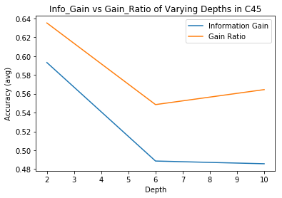

```python
depths = [2,6,10]
#obtained from running the above commands
info_gain = [0.593173338022,0.488540995136,0.485656586376]
gain_ratio = [0.63520775948,0.54850163121,0.564419113481]
plt.plot(depths, info_gain)
plt.plot(depths, gain_ratio)
plt.xlabel('Depth')
plt.ylabel('Accuracy (avg)')
plt.title('Info_Gain vs Gain_Ratio of Varying Depths in C45')
plt.legend(labels=['Information Gain', 'Gain Ratio'])
```

From the table, using the gain ratio has consistently better results than using information gain. This shows us that many of the attributes have a large number of different values. Gain ratio is better because it is able to normalize information gain with respect to the number of unique values per attribute. When looking at the data, we see that this is also true, with 14/18 attributes having more than just binary values. Thus, we'll be using gain ratio when comparing the two algorithms since it has a slightly better performance.

From here, I thought it would be interesting to see how the the decision tree performs when looking at different depths. For the next experiment, I'll be running the decision tree with varying heights of 2, 4, 6, 8, and 10 while using gain ratio (option 4 = 1). As an example, you can use the command:

```
python3 classifier.py dtree bank 0 <2/4/6/8/10> 1
```

where 2/4/6/8/10 is the depth of the tree and 1 is using gain ratio.

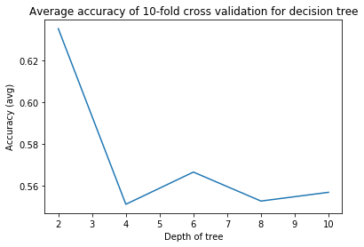

```python
t = arange(2, 12, 2)
#accuracy averages obtained from running the above commands
s = [0.635433882279, 0.550931352439, 0.566424915509, 0.552486862412, 0.556690402235]
plot(t, s)

xlabel('Depth of tree')
ylabel('Accuracy (avg)')
title('Average accuracy of 10-fold cross validation for decision tree')
show()
```

From the graph, accuracy does not improve smoothly as the depth of the tree increases. This is likely a sign that our tree is overfitting the data. Since this is CV accuracy and not overall accuracy, the algorithm trains to be very accurate for the folds that it is trained on, but then not necessarily accurate on data it hasn’t seen before. The pattern of the graph is that CV accuracy decreases and then plateaus to some extent (within 0.1). A possible explanation is that for a while, we overfit to around the 3rd-5th attribute tests. Afterwards, the addition of more attribute tests doesn’t decrease the accuracy anymore as we have already overfit to the previously chosen attributes. In order to test this hypothesis further, let's see what happens when we run the table on the full sample versus cross-validation for depths of 1/2.

```python
print("Full sample - depth 1")
%run classifier.py dtree "bank" 1 1 0
print("\nFull sample - depth 2")
%run classifier.py dtree "bank" 1 2 0
```

```
Full sample - depth 1
Accuracy: 0.885202388852 0.0
Precision: 1.0 0.0
Recall: 0.00383877159309 0.0

Full sample - depth 2
Accuracy: 0.88099977881 0.0
Precision: 0.302325581395 0.0
Recall: 0.0249520153551 0.0
```

```python
print("Cross validation - depth 1")
%run classifier.py dtree "bank" 0 1 0
print("\nCross validation - depth 2")
%run classifier.py dtree "bank" 0 2 0
```

```
Cross validation - depth 1
Accuracy: 0.882990486237 0.0018362725339
Precision: 0.1 0.2
Recall: 0.00384615384615 0.00769230769231

Cross validation - depth 2
Accuracy: 0.599152649983 0.237568849638
Precision: 0.184094258837 0.118914981487
Recall: 0.409433962264 0.271772581142
```

For no cross-validation, adding in the 2nd attribute barely affects the accuracy for the model. This shows evidence for overfitting the data. Since we are using the exact same data to learn annd test the model, it's possible that the decision tree has picked up on some of the noise that exists in the data. In essence, instead of "learning", our tree is "memorizing" all of our data and thus has a very high accuracy. For CV accuracy, the values decrease by a significant amount when increasing the depth just by 1 more. This further supports our hypothesis of overhitting – the data we used to train the decision tree model is not the same criterion when judging the model due to using 10-fold cross validation. In addition, we explored that our dataset has many continuous attributes, which could explain why the accuracy decreases by about 30%. Since the decision tree is not naturally designed to handle continuous attributes, the algorithm may be having difficulty finding an appropriate split.

#### Naive Bayes

```
python3 classifier.py nbayes 0 <4/8/12/16/20> 1
```

in your terminal to run the naive bayes algorithm with 4/8/12/16/20 continuous bins and laplacian smoothing.

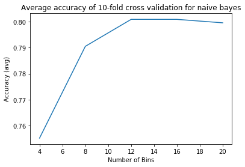

```python
t = arange(4, 24, 4)
#accuracy average of running the above command
s = [0.755148078689, 0.790538982985, 0.80093379437, 0.800933305984, 0.799605383969]
plot(t, s)

xlabel('Number of Bins')
ylabel('Accuracy (avg)')
title('Average accuracy of 10-fold cross validation for naive bayes')
show()
```

As you can see, changing the number of bins doesn't change the accuracy by very much (within 0.05). A possible reason for this is because of the number of continuous values we have. As we mentioned earlier, many of our attributes in the dataset were continuous; however, there is no mention of how many different types of values there are within the attributes. Thus, it's possible that when we split at only 4-8 bins, there was more variety in the values of those attributes that could be split on. As we increase the number of continuous bins for those attributes, it plateaus that shows there is no longer an advantage of continuing to split that much.

### Comparison

Since there is no similar independent variable between the two algorithms (other than the dataset), it's difficult to create a graph comparing them side by side while changing a singular, independent variable. Thus, for our purposes, we will perform a t-test on the cross-validation **folds** of the algorithms. In addition, we will also take a look at how percentage split effects the accuracies of the two algorithms.

##### T-test - Cross Validation

```
python3 classifier.py nbayes bank 0 4 1
python3 classifier.py dtree bank 0 0 1
```

**Note:** For the experiment, I've modified the main method of classifier.py to print each fold. You can do this yourself in line 92/116 of classifier.py. Instead of printing the output at the end of the for-loop, indent it so that it is under the for loop and it prints each fold, aka "statistics.print_output(i)" instead of "statistics.print_output(USE_ALL_TABLES)".

Since we are using 10-fold cross validation, we will have 18 degrees of freedom – 10+10-2. In addition, since are using 95% confidence, our t-value will be 2.10092204. Our null hypothesis is that there is no statistically significant difference between our two algorithms. Here are the results of the running the above commands:

```python
#accuracy of each fold as described in the commands above
table = [["Fold",1,2,3,4,5,6,7,8,9,10,"Mean", "Standard Deviation"],
         ["Error Rate DT",0.22295805739,0.479228935904,0.57874413123,0.47166871789,
          0.53441462033,0.56702693287,0.58368427369,0.52814630585,0.53509760126,
          0.55437545176,0.50544,0.10621853299],
         ["Error Rate NB",0.2495451826,0.23359185242,0.22718503976,0.22776573092,
          0.22594046898,0.2227403767,0.22338234289,0.22314418679,0.22450233449,
          0.224161041909,0.2282,0.00816214344193]]

display(HTML(tabulate.tabulate(table, tablefmt='html')))
```

| Fold | 1 | 2 | 3 | 4 | 5 | 6 | 7 | 8 | 9 | 10 | Mean | Standard Deviation |
| --- | --- | --- | --- | --- | --- | --- | --- | --- | --- | --- | --- | --- |
| Error Rate DT | 0.222958 | 0.479229 | 0.578744 | 0.471669 | 0.534415 | 0.567027 | 0.583684 | 0.528146 | 0.535098 | 0.554375 | 0.50544 | 0.10621853299 |
| Error Rate NB | 0.249545 | 0.233592 | 0.227185 | 0.227766 | 0.22594 | 0.22274 | 0.223382 | 0.223144 | 0.224502 | 0.224161 | 0.2282 | 0.00816214344193 |

In the above table, error rate was calculated through 1 - Accuracy. Now that we have our table of sample means and variances, let's perform the t-test:

Since $$ t_{crit} < t_{stat} $$ or $$ 2.10092204 < 8.2296 $$ we can reject our null hypothesis that there is no statistically significant difference between our two algorithms.

One possible reason for this is our dataset. As we explored earlier, the "bank" dataset has many continuous values and nominal attributes rather than binary attributes. As a result, the decision tree algorithm has a more difficult time splitting between these attributes since it uses a threshold value. On the other hand, our naive bayes algorithm creates multiple "bins" (depending on the input) and categorizes our examples according to the bins. This results in a much more accurate split between the examples, and thus overall accuracy of the resulting model. Although we could have used a lower depth of the tree for the decision tree algorithm, this would have been an inaccurate representation of the performance of the decision tree due to overfitting.

##### Percentage Split

Now that we know naive bayes runs more accurately than decision trees when using cross-validation, it would be interesting to see what it's like when we're using a percentage split. This would mean many more examples for the models to train on, and thus more accurate models – theoretically. We should expect that the accuracy for the decision tree shouldn't change by much since we've tested training it through the entire model.

For this test, I've implemented a seperate file to make it easier to run with less options instead of lumping it together with the classifier.py file. To run this file, the arguments are exactly the same as classifier, but instead of cross-validation, it will take in a percentage. If you want to run this yourself, here are some examples:

```
python3 percentage_split.py dtree bank <90/80/70> 0 1
python3 percentage_split.py nbayes bankn <90/80/70> 4 1
```

where 90/80/70 is the percentage split. To declutter the notebook, I will run it seperately and report the results for 90/80/70/60/50 percent splits.

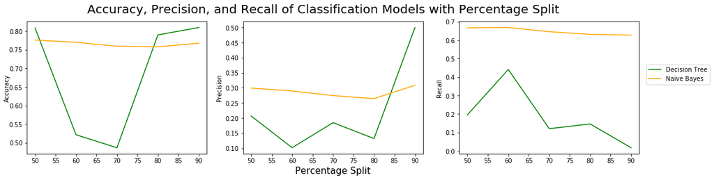

```python
percentage = [90, 80, 70, 60, 50]
#accuracies, precision, and recall averages obtained by running the commands described above
acc_dtree = [0.809734513274, 0.78982300885, 0.486725663717,
             0.52157079646, 0.808407079646]
acc_nbayes = [0.767699115044, 0.757743362832, 0.759587020649,
              0.769911504425, 0.77610619469]
prec_dtree = [0.5, 0.131578947368, 0.184466019417,
              0.101307189542, 0.206349206349]
prec_nbayes = [0.308333333333, 0.264227642276, 0.274193548387,
               0.289527720739, 0.299159663866]
recall_dtree = [0.0169491525424, 0.145631067961, 0.120253164557,
                0.440758293839, 0.194756554307]
recall_nbayes = [0.627118644068, 0.631067961165, 0.645569620253,
                 0.668246445498, 0.666666666667]

f = plt.figure(figsize=(18,4))
ax = f.add_subplot(111)    # The big subplot
#accuracy plot
ax1 = f.add_subplot(131)
ax1.plot(percentage, acc_dtree, color='g')
ax1.plot(percentage, acc_nbayes, color='orange')
#precision plot
ax2 = f.add_subplot(132)
ax2.plot(percentage, prec_dtree, color='g')
ax2.plot(percentage, prec_nbayes, color='orange')
ax2.set_ylabel('Precision', fontsize = 10.0)
#recall plot
ax3 = f.add_subplot(133)
ax3.plot(percentage, recall_dtree, color='g', label="Decision Tree")
ax3.plot(percentage, recall_nbayes, color='orange', label='Naive Bayes')
ax3.set_ylabel('Recall', fontsize = 10.0)
# Turn off axis lines and ticks of the big subplot
ax.spines['top'].set_color('none')
ax.spines['bottom'].set_color('none')
ax.spines['left'].set_color('none')
ax.spines['right'].set_color('none')
ax.tick_params(labelcolor='w', top='off', bottom='off', left='off', right='off')
ax.set_xlabel('Percentage Split', fontsize = 15.0)
ax.set_ylabel('Accuracy', fontsize = 10.0)
#add titles, legend
f.suptitle("Accuracy, Precision, and Recall of Classification Models with Percentage Split", fontsize = 20.0)
handles, labels = ax3.get_legend_handles_labels()
ax.legend(handles, labels, bbox_to_anchor=(1.12, 0.6), loc="center right")
```

From the graph, we can see that the Naive Bayes model for accuracy is pretty consistent throughout all the percentage splits – all within 0.2. Based on what we've found earlier, this is to be expected. Even when changing our percentage split, there is no evidence that it effects the outcome of the model. This suggests that there are certain attributes within our dataset that heavily influece the outcome of the class, particularly the continuous attributes.

### Data Investigation

Now that we see the results of our algorithms, I'm curious to see how the data stacks up and why our algorithms performed the way they did. I printed out the features for these first depths to see how they relate to each other in effect to the resulting class. This code is in lines 89-90 and lines 98-99 in classifier.py. I've commmented out those lines that print to the console to prevent taking up so much space, but you can easily try printing it yourself by uncommenting those lines if you are curious. From those lists, I've taken a couple features (poutcome, previous, day, housing, loan, month) and will plot some heatmaps:

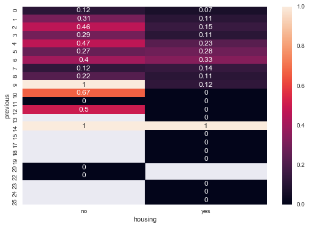

```python
df = pd.read_csv("bank/bank.csv", sep=";")
df.y.replace(['yes', 'no'], [1, 0], inplace=True)
sns.set()
# Load the example flights dataset and conver to long-form
new_df = df.pivot_table(index='previous', columns = 'housing', values = "y")

# Draw a heatmap with the numeric values in each cell
f, ax = plt.subplots(figsize=(9, 6))
sns.heatmap(new_df, annot=True, ax=ax)
```

In real life, it would make sense that someone without housing would require to take out a loan. Let's try a different one

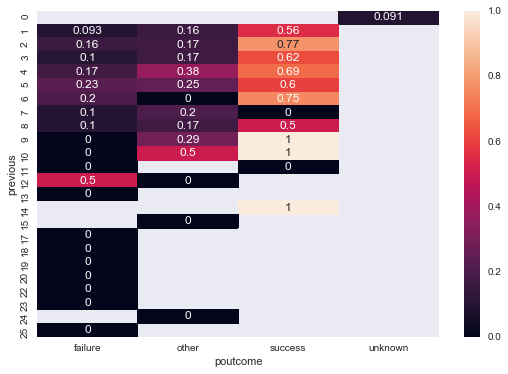

```python
new_df = df.pivot_table(index='previous', columns = 'poutcome', values = "y")

# Draw a heatmap with the numeric values in each cell
f, ax = plt.subplots(figsize=(9, 6))
sns.heatmap(new_df, annot=True, ax=ax)
```

It's interesting to see that many of the categories that affected our decision tree and naive bayes were both continuous and nominal attributes. This supports our theory that the reason why the accuracy for our decision tree model was significantly lower than our naive bayes model since the decision tree isn't naturally designed to handle continuous/nominal attributes.

In addition, in real life, these are the types of categories that I would imagine help decide if a person would subscribe to a term deposit. My initial thought is taht if they had done so previously, they would be more comfortable in doing it again. In addition, if they had done so before and it was successful, I would also imagine that this would help in convincing them to subscribe to a loan again. It's interesting to see that some real life assumptions are supported by these kinds of classification models.

### Conclusion

Overall, this comparison revealed some strengths of weaknesses of decision trees and naive bayes. Naive bayes seems to be more accurate in general as a classification model; however, it's difficult to draw such a hard conclusion before testing the other caveats that we discovered such as the types of attributes in a dataset.

#### Dataset

This leads into our next conclusion. The type of data that we are using to test our algorithms affects the trained model. In the future, if I were deciding on which classification model I want to use, I would want to first take a look at the data before deciding. From the work we did here, it seems that decision trees don't work very well on datasets that have many continuous attributes while naive bayes model can handle it pretty well.

#### Future Work

The first thing I would want to test in the future is how the two algorithms perform on different datasets. It would be interesting to see how the accuracies change for datasets that have more nominal attributes and more binary attributes to see if the decision tree can handle them better and also how the naive bayes model changes. In addition, I would also want to test these algorithms against other classification algorithms such as random forests, neural networks, and SVM algorithms.

## Source Code

Each block contains a comment at the top that shows which file it is.

```python
#classifier.py
#!/usr/bin/python
import sys
from dtree import get_nodes, C45
#get_first_feature, get_second_feature
from dtree import classify as dtree_classify
from nbayes import classify as nbayes_classify
from nbayes import naive_bayes
from util import get_schema, nfold, split_folds, get_examples
from statistics import Statistics
SEED = 12345
NUM_FOLDS = 10
CLASS_IDX = -1
USE_ALL_TABLES = -1

class DTree():

    def __init__(self, file_base, examples, depth, use_gain_ratio):
        self.nodes = get_nodes(file_base)
        self.examples = examples
        self.depth = depth
        if self.depth == 0:
            self.depth = -1
        self.use_gain_ratio = use_gain_ratio
        self.node = C45(self.examples, self.nodes, self.depth, self.use_gain_ratio)
        self.__weight = 1.0

    @property
    def weight(self):
        return self.__weight

    @weight.setter
    def weight(self, weight):
        self.__weight = weight

    def classify(self, example):
        status, confidence = dtree_classify(example, self.node)
        return status, confidence

class NBayes:

    def __init__(self, file_base, examples, num_bins, m_estimate):
        self.__schema = get_schema(file_base)
        self.examples = examples
        self.class_true, self.class_false, self.true_rate, self.false_rate = naive_bayes(examples, self.__schema, num_bins, m_estimate)
        self.__weight = 1.0

    @property
    def weight(self):
        return self.__weight

    @weight.setter
    def weight(self, weight):
        self.__weight = weight

    def classify(self, example):
        __class, confidence = nbayes_classify(
            example, self.__schema, self.class_true, self.class_false, self.false_rate, self.true_rate)
        return __class, confidence


def get_first_feature(tree):
    return tree.get_attribute() if tree.get_attribute() else "None"

def get_second_feature(tree):
    if tree.get_depth() > 1:
        return list(child.get_attribute() if child.get_attribute() else "None" for child in tree.get_children().values())
    else:
        return None

def main(argv):
    #name of the algorithm
    algo = argv[0]
    # path to the data --> load "/a/b/someproblem.names" and "/a/b/someproblem.data"
    path = argv[1]
    examples = get_examples(path)
    if algo == "dtree":
        # 0/1 option, 0 = cross_validation, 1 = full sample
        cross_validation_or_full = int(argv[2])
        # nonnegative integer that sets max depth of the tree, if 0, use full tree
        depth = int(argv[3])
        # 0/1 option, 0 = information gain, 1 = gainratio
        use_gain_ratio = int(argv[4])
        statistics = Statistics()
        if cross_validation_or_full == 0:
            train_sets, test_sets = split_folds(nfold(NUM_FOLDS, path, SEED, examples))
            for i in range(NUM_FOLDS):
                dtree = DTree(path, train_sets[i], depth, use_gain_ratio)
                statistics.store_classified_fold(test_sets[i], dtree)
                #print("First feature: ", get_first_feature(dtree.node))
                #print("Second features: ", get_second_feature(dtree.node))
                #print("Fold",i+1,"accuracy:")
            statistics.print_output(USE_ALL_TABLES)
                #print("\n")
        else:
            dtree = DTree(path, examples, depth, use_gain_ratio)
            statistics.store_classified_fold(examples, dtree)
            statistics.print_output(USE_ALL_TABLES)
            #print("First feature: ", get_first_feature(dtree.node))
            #print("Second features: ", get_second_feature(dtree.node))
            #print(dtree.node)
    if algo == "nbayes":
        # 0/1 option, 0 = cross_validation, 1 = full sample
        cross_validation_or_full = int(argv[2])
        # number of bins per continous attribute (at least 2)
        num_bins = int(argv[3])
        # value of m for the m-estimate. laplace-smoothing if negative, m=0 is maximum likelihood estimate
        # value of p in m-estimate should be fixed to 1/v for variable with v values
        m_estimate = int(argv[4])
        schema = get_schema(path)
        statistics = Statistics()
        if cross_validation_or_full == 0:
            train_sets, test_sets = split_folds(nfold(NUM_FOLDS, path, SEED, examples))
            for i in range(NUM_FOLDS):
                nbayes = NBayes(path, train_sets[i], num_bins, m_estimate)
                statistics.store_classified_fold(test_sets[i], nbayes)
                #print("Fold", i+1, "accuracy:")
            statistics.print_output(USE_ALL_TABLES)
                #print("\n")
        else:
            nbayes = NBayes(path, examples, num_bins, m_estimate)
            statistics.store_classified_fold(examples, nbayes)
            statistics.print_output(USE_ALL_TABLES)


if __name__ == "__main__":
    main(sys.argv[1:])
```

```python
#percentage_split.py
import sys
from classifier import DTree, NBayes
from util import get_schema, nfold, split_folds, get_examples
import random
from statistics import Statistics
SEED = 12345
NUM_FOLDS = 10
CLASS_IDX = -1
USE_ALL_TABLES = -1


def percent_split(percentage, examples, seed):
    #uninversal for examples using parser.py
    class_idx = -1
    #turn int into percentage
    percentage = float(percentage) / 100.0
    num_ex = float(len(examples))
    random.Random(seed).shuffle(examples)
    train_set = examples[:int(num_ex*percentage)]
    test_set = examples[int(num_ex*percentage)+1:]
    return train_set, test_set

def count_pos_neg(examples):
    num_pos = 0
    num_neg = 0
    for ex in examples:
        if ex[-1]:
            num_pos += 1
        else:
            num_neg += 1
    return num_pos, num_neg
def main(argv):
    #name of the algorithm
    algo = argv[0]
    # path to the data --> load "/a/b/someproblem.names" and "/a/b/someproblem.data"
    path = argv[1]
    examples = get_examples(path)
    percent = int(argv[2])
    if algo == "dtree":
        # nonnegative integer that sets max depth of the tree, if 0, use full tree
        depth = int(argv[3])
        # 0/1 option, 0 = information gain, 1 = gainratio
        use_gain_ratio = int(argv[4])
        statistics = Statistics()
        train_set, test_set = percent_split(percent, examples, SEED)
        dtree = DTree(path, train_set, depth, use_gain_ratio)
        statistics.store_classified_fold(test_set, dtree)
        statistics.print_output(USE_ALL_TABLES)
    if algo == "nbayes":
        # number of bins per continous attribute (at least 2)
        num_bins = int(argv[3])
        # value of m for the m-estimate. laplace-smoothing if negative, m=0 is maximum likelihood estimate
        # value of p in m-estimate should be fixed to 1/v for variable with v values
        m_estimate = int(argv[4])
        statistics = Statistics()
        train_set, test_set = percent_split(percent, examples, SEED)
        nbayes = NBayes(path, train_set, num_bins, m_estimate)
        statistics.store_classified_fold(test_set, nbayes)
        statistics.print_output(USE_ALL_TABLES)

if __name__ == "__main__":
    main(sys.argv[1:])
```

```python
#util.py
#!/usr/bin/python
from __future__ import division
from parser import *
import random

def get_schema(file_base):
    es = parse_c45(file_base, "./..")
    return es.schema

def get_examples(file_base):
    es = parse_c45(file_base, "./..")
    return es.examples

def get_accuracy(cont_table):
    true_pos = cont_table[0]
    false_pos = cont_table[1]
    false_neg = cont_table[2]
    true_neg = cont_table[3]
    return (true_pos + true_neg) / (true_pos + true_neg + false_pos + false_neg)


def nfold(n, file_base, seed, examples):
    #universal for examples using parser.py
    class_idx = -1
    folds = [[] for i in range(n)]
    positives = []
    negatives = []
    for example in examples:
        if example[class_idx]:
            positives.append(example)
        else:
            negatives.append(example)

    random.Random(seed).shuffle(positives)
    random.Random(seed).shuffle(negatives)

    fold_idx = 0
    while positives:
        folds[fold_idx].append(positives.pop())
        fold_idx += 1
        fold_idx %= n

    fold_idx = 0
    while negatives:
        folds[fold_idx].append(negatives.pop())
        fold_idx += 1
        fold_idx %= n

    return folds

def split_folds(folds):
    num_folds = len(folds)
    train_sets = [[] for i in range(num_folds)]
    test_sets = [[] for i in range(num_folds)]
    for omit in range(num_folds):
        for i in range(num_folds):
            if i == omit:
                test_sets[omit] += folds[i]
            else:
                train_sets[omit] += folds[i]

    return train_sets, test_sets
```

```python
#csv_to_c45.py
import pandas as pd
from dateutil import parser
import time
import datetime

def make_data(df, filename):
    f = open(filename, "w")
    row_idx = 0
    count_yes = 0
    count_no = 0
    for row in df.values:
        end_idx = len(row)
        idx = 0
        subscribed = False #bank classifier
        for value in row:
            if idx == 0:
                f.write(str(row_idx) + ",")
                row_idx += 1
            value = str(value)
            value.replace('"','')

            if value == "admin.":
                value = "admin"

            if idx == end_idx-1:
                if value == "yes":
                    subscribed = True
                continue
            f.write(str(value) + ",")
            idx += 1

        if subscribed:
            f.write("1")
            count_yes += 1
        else:
            f.write("0")
            count_no += 1
        f.write("\n")
    print(count_no)
    print(count_yes)

def make_names(df, filename):
    f = open(filename, "w")
    f.write("0,1.\n")
    f.write("id: ")
    for i in range(len(df)):
        f.write(str(i) + ",")
    f.write("\n")
    for column_idx in range(0, len(df)):
        if column_idx == len(df)-1: # skip class
            continue
        column_name = df.columns[column_idx]
        f.write(column_name + ": ")
        value_set = set([])
        for row in df.values:
            value_set.add(row[column_idx])

        end_idx = len(value_set)
        idx = 0
        for value in value_set:
            value = str(value)
            value.replace('"', '')
            f.write(value)

            if idx == end_idx - 1:
                f.write(".")
            else:
                f.write(", ")
            idx += 1

        f.write("\n")


def main():
    df = pd.read_csv("./bank/bank.csv", sep=";")
    #make_names(df, "./bank/bank.names")
    make_data(df, "./bank/bank.data")


if __name__ == "__main__":
    main()
```

```python
#statistics.py
#!/usr/bin/python
from __future__ import division
from numpy import zeros
USE_ALL_TABLES = -1
CLASS_IDX = -1

class Statistics:

    def __init__(self):
        self.cont_tables = []
        self.confidence_dicts = []  # array of dictionaries that map confidence level -> tested class values

    def add_cont_table(self, cont_table):
        self.cont_tables.append(cont_table)

    #fold: average of all folds if -1 else specified fold number
    def print_output(self, fold):
        mean, std_dev = self.metric(Cont_Table.accuracy, fold)
        print("Accuracy: " + str(mean) + " " + str(std_dev))
        mean, std_dev = self.metric(Cont_Table.precision, fold)
        print("Precision: " + str(mean) + " " + str(std_dev))
        mean, std_dev = self.metric(Cont_Table.recall, fold)
        print("Recall: " + str(mean) + " " + str(std_dev))
        #print("Area under ROC: " + str(self.area_under_roc(num_folds)))

    #run metric test on the specified fold
    def metric(self, metric_test, fold):
        if fold == USE_ALL_TABLES:
            values = self.on_all_tables(metric_test)
            return self.get_mean(values), self.get_std_dev(values)
        else:
            return metric_test(self.cont_tables[fold])

    #returns list of results of the input test on all cont tables
    def on_all_tables(self, metric_test):
        values = zeros(len(self.cont_tables))
        for i in range(0, len(self.cont_tables)):
            values[i] = metric_test(self.cont_tables[i])

        return values

    #gets standard deviation of a list of values
    def get_std_dev(self, values):
        std_dev = 0
        mean = self.get_mean(values)
        for value in values:
            std_dev += (value - mean) ** 2

        return (std_dev / len(values)) ** 0.5

    #gets mean of a list of values
    def get_mean(self, values):
        mean = 0
        for value in values:
            mean += value

        return mean / len(values)

    def store_classified_fold(self, test_set, classifier):
        cont_table = Cont_Table()
        confidence_dict = {}
        for example in test_set:
            tested_class, confidence = classifier.classify(example)
            cont_table.add_to_table(tested_class, example[CLASS_IDX])
            if confidence in confidence_dict:
                confidence_dict[confidence].append(example[CLASS_IDX])
            else:
                confidence_dict[confidence] = [example[CLASS_IDX]]
        self.confidence_dicts.append(confidence_dict)
        self.cont_tables.append(cont_table)

    #using trapezoidal integration
    #false positive (1-specificity) vs sensitivity/recall
    #specificity = TN / (TN + FP)
    #recall = TP / (TP + FN)
    def area_under_roc(self, num_folds=1):
        # area of a trapezoid formula:
        # (a+b)*h/2
        #(tp1 + tp2) * (fp2-fp1)/2
        area = 0
        for i in range(0, len(self.confidence_dicts)):
            confidence_dict = self.confidence_dicts[i]
            total_true, total_false = self.count_trues_and_falses(self.cont_tables[i])
            keylist = sorted(confidence_dict.keys(), reverse=True)
            TP_rate = 0.0
            FP_rate = 0.0
            num_tp = 0.0
            num_tn = total_false
            for confidence in keylist[0:]:
                for class_val in confidence_dict[confidence]:
                    if class_val:
                        num_tp += 1.0
                    else:
                        num_tn -= 1.0
                new_TP_rate = 1.0 if total_true == 0 else num_tp / total_true
                new_FP_rate = 0.0 if total_false == 0 else 1 - (num_tn / total_false)
                area += (new_TP_rate + TP_rate) * (new_FP_rate - FP_rate) / 2.0
                FP_rate = new_FP_rate
                TP_rate = new_TP_rate
        return area/num_folds

    def count_trues_and_falses(self, cont_table):
            return cont_table[0] + cont_table[2], cont_table[1] + cont_table[3]

    def print_table(self, fold):
        print(self.cont_tables[fold])


class Cont_Table:
    #indexes in contingency table
    TRUE_POS = 0
    TRUE_NEG = 3
    FALSE_POS = 1
    FALSE_NEG = 2

    def __init__(self):
        self.cont_table = zeros(4)

    def add_to_table(self, tested_class, real_class):
        self.cont_table[self.cont_index(tested_class, real_class)] += 1

    def cont_index(self, tested_class, example_class):
        if example_class == tested_class:
            #example true, tested true
            if example_class:
                return self.TRUE_POS
            #example false, tested false
            else:
                return self.TRUE_NEG
        else:
            #example true, tested false
            if example_class:
                return self.FALSE_NEG
            #example false, tested true
            else:
                return self.FALSE_POS

    #fold: use cont_table resulting from fold number
    def accuracy(self):
        true_pos = self.cont_table[self.TRUE_POS]
        false_pos = self.cont_table[self.FALSE_POS]
        false_neg = self.cont_table[self.FALSE_NEG]
        true_neg = self.cont_table[self.TRUE_NEG]
        return (true_pos + true_neg) / (true_pos + true_neg + false_pos + false_neg)

    #fold: use cont_table resulting from fold number
    def precision(self):
        true_pos = self.cont_table[self.TRUE_POS]
        false_pos = self.cont_table[self.FALSE_POS]
        return 0 if true_pos+false_pos == 0 else true_pos / (true_pos + false_pos)

    #fold: use cont_table resulting from fold number
    def recall(self):
        true_pos = self.cont_table[self.TRUE_POS]
        false_neg = self.cont_table[self.FALSE_NEG]
        return 0 if true_pos+false_neg == 0 else true_pos / (true_pos + false_neg)

    def __getitem__(self, idx):
        return self.cont_table[idx]

    def __str__(self):
        return "TP: %d, FN: %d, FP: %d, TN: %d" % (
            self.cont_table[self.TRUE_POS], self.cont_table[self.FALSE_NEG], self.cont_table[self.FALSE_POS], self.cont_table[self.TRUE_NEG])
```

```python
#parser.py
"""
This module contains functions and classes used to parse and
represent data stored in the C4.5 format.

An Example is a list of Features that complies to some
Schema, which describes feature types and values. An
ExampleSet is a list of Examples that all comply to the same
Schema.

ExampleSets, Examples, and Schemas all implement the
necessary sequence methods so that syntax like:

>>> dataset[i][j]

gives the jth value of the ith example, and:

>>> for example in dataset: ...

iterates through examples in the dataset.

"""
import re
import sys
import collections

###############################################################################
#                     CODE FOR FEATURES, EXAMPLES, ETC.                       #
###############################################################################


class Feature(object):
    """
    Describes a feature by name, type, and values
    """

    class Type:
        """
        Enumerate types of features
        """
        CLASS = 'CLASS'
        ID = 'ID'
        BINARY = 'BINARY'
        NOMINAL = 'NOMINAL'
        CONTINUOUS = 'CONTINUOUS'

    def __init__(self, name, ftype, values=None):
        self.name = name
        self.type = ftype
        if (self.type == Feature.Type.ID or
                self.type == Feature.Type.NOMINAL):
            if values is None:
                raise Exception('No values for %s feature' % self.type)
            else:
                self.values = tuple(values)
        else:
            if values is None:
                self.values = None
            else:
                raise Exception('Values given for % feature' % self.type)
        self.tup = (self.name, self.type, self.values)

    def __cmp__(self, other):
        if self.tup > other.tup:
            return 1
        elif self.tup < other.tup:
            return -1
        else:
            return 0

    def __hash__(self):
        return self.tup.__hash__()

    def __repr__(self):
        return '<%s, %s, %s>' % self.tup

    def to_float(self, value):
        if value is None:
            return None
        if (self.type == Feature.Type.ID or
                self.type == Feature.Type.NOMINAL):
            return float(self.values.index(value))
        elif (self.type == Feature.Type.BINARY or
              self.type == Feature.Type.CLASS):
            if value:
                return 1.0
            else:
                return 0.0
        else:
            return value


# Class label: special singleton feature
Feature.CLASS = Feature("CLASS", Feature.Type.CLASS)


class Schema(collections.Sequence):
    """
    Represents a schema for C4.5 data
    as a sequence of features
    """

    def __init__(self, features):
        self.features = tuple(features)

    def __cmp__(self, other):
        if self.features > other.features:
            return 1
        elif self.features < other.features:
            return -1
        else:
            return 0

    def __hash__(self):
        return self.features.__hash__()

    def __repr__(self):
        return str(self.features)

    def __len__(self):
        return len(self.features)

    def __iter__(self):
        return self.features.__iter__()

    def __contains__(self, item):
        return self.features.__contains__(item)

    def __getitem__(self, key):
        return self.features[key]


class ExampleSet(collections.MutableSequence):
    """
    Represents a sequence of examples that
    all comply to the same schema
    """

    def __init__(self, schema_or_seq=None):
        self.examples = []
        if schema_or_seq is None:
            self.schema = None
        elif type(schema_or_seq) == Schema:
            self.schema = schema_or_seq
        else:
            self.schema = None
            try:
                self += schema_or_seq
            except:
                raise ValueError('Argument must be schema or list of examples')

    def to_float(self, mapper=None):
        """
        Convert this example set into a list of list
        of floats. Useful for constructing NumPy arrays.

        The mapper is a function applied to each example
        after it has been turned into a list of floats,
        and can be used to standardize data, for example.

        """
        return [ex.to_float(mapper) for ex in self]

    def schema_check(arg):
        """
        Wraps call to function f with a schema
        check on the argument specified by 'arg.'
        """
        def outer_wrapper(f):
            def inner_wrapper(self, *args, **kwargs):
                # Check Schema (if one exists)
                if (self.schema is not None and
                        args[arg].schema != self.schema):
                    raise ValueError('Schema mismatch')

                # Call function
                retval = f(self, *args, **kwargs)

                # If successful, set schema if none
                if self.schema is None:
                    self.schema = args[arg].schema

                return retval

            return inner_wrapper
        return outer_wrapper

    def __len__(self):
        return len(self.examples)

    def __iter__(self):
        return self.examples.__iter__()

    def __contains__(self, item):
        return self.examples.__contains__(item)

    def __getitem__(self, key):
        return self.examples[key]

    @schema_check(1)
    def __setitem__(self, key, example):
        self.examples[key] = example

    def __delitem__(self, key):
        del self.examples[key]

    @schema_check(1)
    def insert(self, key, example):
        return self.examples.insert(key, example)

    @schema_check(0)
    def append(self, example):
        super(ExampleSet, self).append(example)

    def __repr__(self):
        return '<%s, %s>' % (repr(self.schema), repr(self.examples))

    def __str__(self):
        return '[%s]' % ',\n '.join(map(str, self.examples))


class Example(collections.MutableSequence):
    """
    Represents a single example
    from a dataset
    """
```

```python
    def __init__(self, schema):
        self.schema = schema
        self.features = [None for i in range(len(schema))]
        self.weight = 1.0

    def to_float(self, mapper=None):
        raw_list = [feature.to_float(value)
                    for feature, value in zip(self.schema, self)]
        if mapper is None:
            return raw_list
        else:
            return mapper(raw_list)

    def __len__(self):
        return len(self.features)

    def __iter__(self):
        return self.features.__iter__()

    def __contains__(self, item):
        return self.features.__contains__(item)

    def __getitem__(self, key):
        return self.features[key]

    def __setitem__(self, key, value):
        self.features[key] = value

    def __delitem__(self, key):
        del self.features[key]

    def insert(self, key, item):
        return self.features.insert(key, item)

    def __repr__(self):
        return '<%s, %s, %s>' % tuple(
            map(repr, (self.schema, self.features, self.weight)))

    def __str__(self):
        return str(self.features)

###############################################################################
#                            CODE TO PARSE C4.5                               #
###############################################################################


_NAMES_EXT = '.names'
_DATA_EXT = '.data'

_COMMENT_RE = '//.*'
_BINARY_RE = '\\s*0\\s*,\\s*1\\s*'


def parse_c45(file_base, rootdir='.'):
    """
    Returns an ExampleSet from the parsed C4.5-formatted data file

    Arguments:
    file_base -- basename of the file, as in 'file_base.names'
    rootdir   -- root of directory tree to search for files

    """
    schema_name = file_base + _NAMES_EXT
    schema_filename = _find_file(schema_name, rootdir)
    if schema_filename is None:
        raise ValueError('Schema file not found')

    data_name = file_base + _DATA_EXT
    data_filename = _find_file(data_name, rootdir)
    if data_filename is None:
        raise ValueError('Data file not found')

    return _parse_c45(schema_filename, data_filename)


def _parse_c45(schema_filename, data_filename):
    """Parses C4.5 given file names"""
    try:
        schema = _parse_schema(schema_filename)
    except Exception as e:
        import traceback
        traceback.print_exc(file=sys.stderr)
        raise Exception('Error parsing schema: %s' % e)

    try:
        examples = _parse_examples(schema, data_filename)
    except Exception as e:
        import traceback
        traceback.print_exc(file=sys.stderr)
        raise Exception('Error parsing examples: %s' % e)

    return examples


def _parse_schema(schema_filename):
    """Parses C4.5 '.names' schema file"""
    features = []
    needs_id = True
    with open(schema_filename) as schema_file:
        for line in schema_file:
            feature = _parse_feature(line, needs_id)
            if feature is not None:
                if (needs_id and feature.type == Feature.Type.ID):
                    needs_id = False
                features.append(feature)

    # Fix the problem that the class feature is listed first in the
    # '.names' file, but is the last feature in the '.data' file
    try:
        features.remove(Feature.CLASS)
    except:
        raise Exception('File does not contain "Class" line')
    features.append(Feature.CLASS)

    return Schema(features)


def _parse_feature(line, needs_id):
    """
    Parse a feature from the given line. The second argument
    indicates whether we need an ID for our schema, in which
    case the first non-CLASS feature is selected.

    """
    line = _trim_line(line)
    if len(line) == 0:
        # Blank line
        return None
    if re.match(_BINARY_RE, line) is not None:
        # Class feature
        return Feature.CLASS
    colon = line.find(':')
    if colon < 0:
        raise Exception('No feature name found.')
    name = line[:colon].strip()
    remainder = line[colon + 1:]
    values = _parse_values(remainder)
    if needs_id:
        return Feature(name, Feature.Type.ID, values)
    elif len(values) == 1 and values[0].startswith('continuous'):
        return Feature(name, Feature.Type.CONTINUOUS)
    elif len(values) == 2 and '0' in values and '1' in values:
        return Feature(name, Feature.Type.BINARY)
    else:
        return Feature(name, Feature.Type.NOMINAL, values)


def _parse_values(value_string):
    """Parse comma-delimited values from a string"""
    values = list()
    for raw in value_string.split(','):
        raw = raw.strip()
        if len(raw) > 1 and raw[0] == '"' and raw[-1] == '"':
            raw = raw[1:-1].strip()
        values.append(raw)
    return values


def _parse_examples(schema, data_filename):
    """Parse examples from a '.data' file given a schema"""
    exset = ExampleSet(schema)
    with open(data_filename) as data_file:
        for line in data_file:
            line = _trim_line(line)
            if len(line) == 0:
                # Skip blank line
                continue
            try:
                ex = _parse_example(schema, line)
                exset.append(ex)
            except Exception as e:
                import traceback
                traceback.print_exc(file=sys.stderr)
                print >> sys.stderr, 'Warning: skipping line: "%s"' % line

    return exset


def _parse_example(schema, line):
    """Parse a single example from the line of a data file"""
    values = _parse_values(line)
    if len(values) != len(schema):
        raise Exception('Feature-data size mismatch: %s' % line)

    ex = Example(schema)
    for i, value in enumerate(values):
        if value == '?':
            # Unknown value remains 'None'
            continue

        # Cast to proper type
        stype = schema[i].type
        if (stype == Feature.Type.ID or
                stype == Feature.Type.NOMINAL):
            ex[i] = value
        elif (stype == Feature.Type.BINARY or
              stype == Feature.Type.CLASS):
            ex[i] = bool(int(value))
        elif stype == Feature.Type.CONTINUOUS:
            ex[i] = float(value)
        else:
            raise ValueError('Unknown schema type "%s"' % stype)
```

```python
    return ex


def _trim_line(line):
    """Removes comments and periods from the given line"""
    line = re.sub(_COMMENT_RE, '', line)
    line = line.strip()
    if len(line) > 0 and line[-1] == '.':
        line = line[:-1].strip()
    return line


def _find_file(filename, rootdir):
    """
    Finds a file with filename located in some
    subdirectory of the root directory
    """
    import os
    for dirpath, _, filenames in os.walk(rootdir):
        if filename in filenames:
            return os.path.join(dirpath, filename)
```

```python
#tree_struct.py
class Node:

    def __init__(self, attribute, attribute_index, attribute_type, test):
        self.attribute = attribute
        self.attribute_index = attribute_index
        self.attribute_type = attribute_type
        self.__test = test
        self.__entropy = None
        self.children = {}

    def __str__(self, level=0):
        ret = "\t"*level+repr(self.get_attribute())+"\n"
        for key in self.children:
            child = self.children[key]
            ret += child.__str__(level+1)
        return ret

    def __repr__(self):
        return '<tree node representation>'

    def get_children(self):
        return self.children

    def get_attribute(self):
        return self.attribute

    def get_attribute_index(self):
        return self.attribute_index

    @property
    def test(self):
        return self.__test

    @test.setter
    def test(self, test):
        self.__test = test

    @property
    def entropy(self):
        return self.__entropy

    @entropy.setter
    def entropy(self, entropy):
        self.__entropy = entropy

    def add_child(self, child):
        if isinstance(child, Node):
            self.children.append(child)

    def get_size(self):
        size = 1
        for key in self.children:
            child = self.children[key]
            size += child.get_size()

        return size

    def get_depth(self):
        if not self.children:
            return 1
        else:
            #return max of the depths + current node
            return max(self.children[key].get_depth() for key in self.children) + 1


class LeafNode:
    def __init__(self, status, confidence):
        self.status = status
        self.confidence = confidence

    def __str__(self, level=0):
        ret = "\t"*level+repr(self.get_attribute())+"\n"
        return ret

    def get_status(self):
        return self.status

    def get_attribute(self):
        if self.status:
            return "Positive Leaf"
        else:
            return "Negative Leaf"

    def get_children(self):
        return []

    def get_depth(self):
        return 1

    def get_size(self):
        return 1
```

```python
#dtree.py
#!/usr/bin/python
from __future__ import division
import sys
from tree_struct import Node, LeafNode
from util import get_schema, get_examples
from parser import *
from statistics import Statistics
import random
import math
SEED = 12345
NUM_FOLDS = 5
USE_ALL_TABLES = -1
CLASS_IDX = -1

def discr_attr_test(schema, examples, feature_idx):
    buckets = {}
    f_values = schema[feature_idx].values
    if f_values:
        for f_value in f_values:
            buckets[f_value] = [[],[]]
    else:
        buckets[True] = [[],[]]
        buckets[False] = [[],[]]
    buckets[None] = [[],[]]

    for example in examples:
        key = example[feature_idx]
        if example[CLASS_IDX]:
            buckets[key][0].append(example)
        else:
            buckets[key][1].append(example)
    return buckets


def cont_attr_test(examples, feature_idx):
    threshold = feature_value_threshold(examples, feature_idx)
    buckets = {None: [[],[]], threshold: [[],[]]}
    i = 0
    for example in examples:
        i += 1
        key = example[feature_idx] < threshold
        if example[CLASS_IDX]:
            buckets[None if key else threshold][0].append(example)
        else:
            buckets[None if key else threshold][1].append(example)
    return buckets


def feature_value_threshold(examples, feature_idx):
    # Sort the examples by their continuous attr value
    examples.sort(key=(lambda example: example[feature_idx]))

    positives, negatives = get_positives_negatives(examples)
    positives = set(positives)
    negatives = set(negatives)

    threshold = examples[0][feature_idx] - 1
    left_bucket = [set([]),set([])]
    right_bucket = [positives,negatives]
    pos_weight = total_weight(positives)
    neg_weight = total_weight(negatives)
    min_entropy = entropy({0: left_bucket, 1: right_bucket}, pos_weight, neg_weight)
    for i in range(1, len(examples)):  # Determine if we should split between i-1 and i
        prev_example = examples[i - 1]
        curr_example = examples[i]
        prev_example_feature_value = prev_example[feature_idx]
        curr_example_feature_value = curr_example[feature_idx]
        prev_example_class = prev_example[CLASS_IDX]
        curr_example_class = curr_example[CLASS_IDX]

        if prev_example_class:
            left_bucket[0].add(prev_example)
            if prev_example in right_bucket[0]:
                right_bucket[0].remove(prev_example)
        else:
            left_bucket[1].add(prev_example)
            if prev_example in right_bucket[1]:
                right_bucket[1].remove(prev_example)

        if prev_example_class != curr_example_class:
            split_entropy = entropy(
                {0: left_bucket, 1: right_bucket}, pos_weight, neg_weight)
            if split_entropy < min_entropy:
                threshold = (prev_example_feature_value +
                             curr_example_feature_value) / 2
                min_entropy = split_entropy
    return threshold

def get_positives_negatives(examples):
    positives = []
    negatives = []
    for example in examples:
        if example[CLASS_IDX]:
            positives.append(example)
        else:
            negatives.append(example)
    return positives, negatives

def get_nodes(file_base):
    node_list = []
    schema = get_schema(file_base)
    examples = get_examples(file_base)

    for feature_idx in range(0, len(schema)):
        feature = schema[feature_idx]
        if feature.type is Feature.Type.NOMINAL or feature.type is Feature.Type.BINARY:
            node = Node(feature.name, feature_idx, feature.type, (lambda examples,
                                                    feature_idx=feature_idx,
                                                    schema=schema: discr_attr_test(schema, examples, feature_idx)))
            node.entropy = attr_entropy(node, examples)
            node_list.append(node)
        elif feature.type is Feature.Type.CONTINUOUS:
            node = Node(feature.name, feature_idx, feature.type, (lambda examples,
                                                    feature_idx=feature_idx: cont_attr_test(examples, feature_idx)))
            node.entropy = attr_entropy(node, examples)
            node_list.append(node)
    return set(node_list)

# example_set: set of examples
# classification_index: index of classification field of each example
# available_attributes: array of nodes that represent each attribute that can still be used
# remaining_depth: integer that tells us how many more layers to go. If 0 stop
# gain_ratio: if == 1, use gain ratio instead of just information gained
#returns a Node
def C45(examples, nodes, remaining_depth, use_gain_ratio):
    total = total_weight(examples)
    num_positive = count_num_pos(examples)
    if num_positive == total:
        return LeafNode(True, 1.0)
    if num_positive == 0:
        return LeafNode(False, 0.0)
    # if there are no more attributes to divide on, return leaf node of majority class
    if not len(nodes) or not remaining_depth:
        return LeafNode(True if num_positive > total/2 else False, num_positive / total if num_positive > total/2 else 1 - (num_positive / total))

    best_node = nodes.pop()
    nodes.add(best_node)
    determining_factor = 0  # Best information gain or gain ratio
    positives, negatives = get_positives_negatives(examples)
    pos_weight = total_weight(positives)
    neg_weight = total_weight(negatives)
    current_entropy = entropy({0: [positives, negatives]}, pos_weight, neg_weight)
    #find the best node using gain_ratio/information_gain
    for node in nodes:
        buckets = node.test(examples)
        entropy_after = entropy(buckets, pos_weight, neg_weight)
        current_determining_factor = 0
        information_gain = current_entropy - entropy_after
        if use_gain_ratio:
            current_determining_factor = information_gain / node.entropy
        else:
            current_determining_factor = information_gain

        # store if max information gained
        if current_determining_factor > determining_factor:
            best_node = node
            determining_factor = current_determining_factor

    if determining_factor == 0:
        return LeafNode(True if num_positive > total/2 else False, num_positive / total if num_positive > total/2 else 1 - (num_positive / total))

    # split on attribute with most information gain and create children
    buckets = best_node.test(examples)
    children = {}
    for key in buckets:
        bucket = buckets[key]
        bucket_examples = bucket[0] + bucket[1]
        nodes.remove(best_node)
        children[key] = (C45(bucket_examples, nodes,
                            remaining_depth-1, use_gain_ratio))
        nodes.add(best_node)
    best_node.children = children
    return best_node

def attr_entropy(node, examples):
    buckets = node.test(examples)
    tot = len(examples)

    entropy = 0
    for key in buckets:
        bucket = buckets[key]
        bucket_length = len(bucket)
        bucket_prob = bucket_length / tot
        bucket_entropy = 0.0 if not bucket_prob else - \
            bucket_prob * math.log(bucket_prob, 2)
        entropy += bucket_entropy
    return entropy

# buckets is a dictionary that maps bucket_idx -> [positives,negatives]
def entropy(buckets, pos_weight, neg_weight):
    num_examples = 0
    for key in buckets:
        bucket = buckets[key]
        num_examples += pos_weight + neg_weight
    entropy = 0
    for key in buckets:
        bucket = buckets[key]
        num_pos = pos_weight
        num_neg = neg_weight
        bucket_size = num_pos + num_neg
        entropy += (bucket_size / num_examples) * bucket_entropy(num_pos, bucket_size)
    return entropy

# Calculate a bucket's entropy based on the number of positive examples and total examples
def bucket_entropy(num_pos, tot):
    if not tot:
        return 0.0
    pos_prob = num_pos / tot
    neg_prob = 1.0 - pos_prob
    pos_entropy = 0 if not pos_prob else pos_prob * math.log(pos_prob, 2)
    neg_entropy = 0 if not neg_prob else neg_prob * math.log(neg_prob, 2)
    return -(pos_entropy + neg_entropy)

def count_num_pos(examples):
    num_pos = 0
    for example in examples:
        if example[CLASS_IDX]:
            num_pos += example.weight
    return num_pos

def total_weight(examples):
    sum = 0
    for example in examples:
        sum += example.weight
    return sum

#returns the accuracy of the tree based on
def classify(example, node):
    if isinstance(node, LeafNode):
        return node.status, node.confidence
    else:
        attribute_value = example[node.attribute_index]
        #hack for getting the threshold
        if node.attribute_type == Feature.Type.CONTINUOUS:
            threshold = None
            for key in node.children:
                if key != None:
                    threshold = key

            if attribute_value < threshold:
                child = node.children[None]
            else:
                child = node.children[threshold]
        else:
            child = node.children[attribute_value]

        return classify(example, child)


def get_first_feature(tree):
    return tree.get_attribute() if tree.get_attribute() else "None"

def get_second_feature(tree):
    if tree.get_depth() > 1:
        return tree.children().str()
    else:
        return None
```

```python
#nbayes.py
#!/usr/bin/python
from __future__ import division
import sys
from util import get_schema, get_examples
from parser import *
from statistics import Statistics
import random
import math
SEED = 12345
NUM_FOLDS = 5
CLASS_IDX = -1
infinity = float("inf")
n_infinity = -float("inf")
USE_ALL_TABLES = -1

#creates two dictionaries, feature names -> dictionaries that map feature value -> # true/false examples
#includes None values in case some feature values are only for +/- examples
def init_class_dict(schema, examples, num_bins):
    class_true = {}
    class_false = {}
    for feature_idx in range(len(schema)):
        feature = schema[feature_idx]
        if feature.name == "CLASS" or feature.name == "id" or feature.name == "index":
            continue
        class_true_dict = {}
        class_false_dict = {}
        class_true[feature.name] = class_true_dict
        class_false[feature.name] = class_false_dict
        if feature.type == Feature.Type.NOMINAL:
            for fvalue in feature.values:
                class_true_dict[fvalue] = 0
                class_false_dict[fvalue] = 0
                class_true_dict[None] = 0
                class_false_dict[None] = 0
        elif feature.type == Feature.Type.BINARY:
            class_true_dict[True] = 0
            class_true_dict[False] = 0
            class_true_dict[None] = 0
            class_false_dict[True] = 0
            class_false_dict[False] = 0
            class_false_dict[None] = 0
        elif feature.type == Feature.Type.CONTINUOUS:
            ranges = get_continuous_ranges(examples, feature_idx, num_bins)
            for tup in ranges:
                class_true_dict[tup] = 0
                class_false_dict[tup] = 0
    return class_true, class_false

#returns two dictionaries and two probabilities as one tuple
def naive_bayes(examples, schema, num_bins, m_value):
    true_total = 0
    false_total = 0

    class_true, class_false = init_class_dict(schema, examples, num_bins)

    for example in examples:
        class_is_true = example[CLASS_IDX]
        corr_dict = class_true if class_is_true else class_false

        if class_is_true:
            true_total += 1
        else:
            false_total += 1

        for feature_idx in range(0, len(example)):
            feature = schema[feature_idx]
            if feature.type == Feature.Type.CONTINUOUS or feature.type == Feature.Type.BINARY or feature.type == Feature.Type.NOMINAL:
                feature_value = example[feature_idx]
                fvalue_dict = corr_dict[feature.name]

                if feature.type == Feature.Type.CONTINUOUS:
                    feature_value = get_continuous_feature_key(feature_value, fvalue_dict)

                fvalue_dict[feature_value] += example.weight

    count_to_prob(class_true, true_total, m_value)
    count_to_prob(class_false, false_total, m_value)
    total = true_total + false_total

    return (class_true, class_false, true_total / total, false_total / total)


def get_continuous_ranges(examples, feature_idx, num_bins):
    ranges = []
    examples.sort(key=(lambda example: example[feature_idx]))
    bin_sizes = []
    leftover = len(examples) % num_bins
    for i in range(0, num_bins):
        bin_sizes.append(int(len(examples) / num_bins))
    for i in range(0, leftover):
        bin_sizes[i] += 1

    start = 0
    prev_range_end = n_infinity
    for idx in range(0, len(bin_sizes)):
        bin_size = bin_sizes[idx]
        range_start = prev_range_end
        range_end = infinity if idx == len(
            bin_sizes) - 1 else examples[start + bin_size - 1][feature_idx]
        prev_range_end = range_end
        ranges.append((range_start, range_end))
        start += bin_size - 1
    return ranges

#calculates probability for each f_value in the +/-
def count_to_prob(nbayes_dict, total, default_m_value):
    for feature_name in nbayes_dict:
        f_value_dict = nbayes_dict[feature_name]
        num_values = len(f_value_dict)
        m_value = num_values if default_m_value < 0 else default_m_value
        if num_values == 0:
            print(feature_name)
        p_value = 1 / num_values
        for f_value in f_value_dict:
            f_value_dict[f_value] = (f_value_dict[f_value] + (m_value * p_value)) / (total + p_value)

def classify(example, schema, dict_class_true, dict_class_false, prob_true, prob_false):
    hypothesis_true = 0
    hypothesis_false = 0
    for feature_idx in range(0, len(example)):
        feature = schema[feature_idx]
        #if feature is not an id/class
        if feature.type == Feature.Type.CONTINUOUS or feature.type == Feature.Type.BINARY or feature.type == Feature.Type.NOMINAL:
            feature_name = schema[feature_idx].name
            feature_value = example[feature_idx]
            true_feature_key = example[feature_idx]
            false_feature_key = example[feature_idx]
            feature_is_continuous = schema[feature_idx].type is Feature.Type.CONTINUOUS

            # dict of the feature if class = true
            feature_dict_true = dict_class_true[feature_name]
            feature_dict_false = dict_class_false[feature_name]
            if feature_is_continuous:
                true_feature_key = get_continuous_feature_key(feature_value, feature_dict_true)
                false_feature_key = get_continuous_feature_key(feature_value, feature_dict_false)

            #add prob to hypothesis_true
            prob = feature_dict_true[true_feature_key] if true_feature_key in feature_dict_true else 0
            if prob != 0:
                hypothesis_true += math.log(prob)

            #add prob to hypothesis_false
            prob = feature_dict_false[false_feature_key] if false_feature_key in feature_dict_false else 0
            if prob != 0:
                hypothesis_false += math.log(prob)

    if hypothesis_true > hypothesis_false:
        return True, hypothesis_true
    else:
        return False, hypothesis_false


def get_continuous_feature_key(val, f_value_dict):
    for key in f_value_dict:
        if key[0] < val <= key[1]:
            return key
    return None
```